# Quantum Convolutional Neural Networks

How well can QML classify classical datasets? In this work (https://arxiv.org/abs/2108.00661), we use various Quantum Convolutional Neural Networks (QCNN) for image data classification tasks. We benchmarked various QCNN models differentiated by structures of parameterized quantum circuits, quantum data encoding methods, classical data pre-processing methods, cost functions and optimizers on MNIST and Fashion MNIST datasets. This is a introductory tutorial for the paper and the full code can be found in https://github.com/takh04/QCNN.

QCNN is a local and translationally invariant variational quantum model suggested by Cong et al (https://arxiv.org/abs/1810.03787). One of the key feature of QCNN is it reduces the number of qubit each layer. Due to its similarity with classical convolutional neural networks, people often use the term convolutional and pooling layers. The original work uses QCNN to classify quantum data in quantum phase recognition problem. Here, we will focus on classifying classical data.

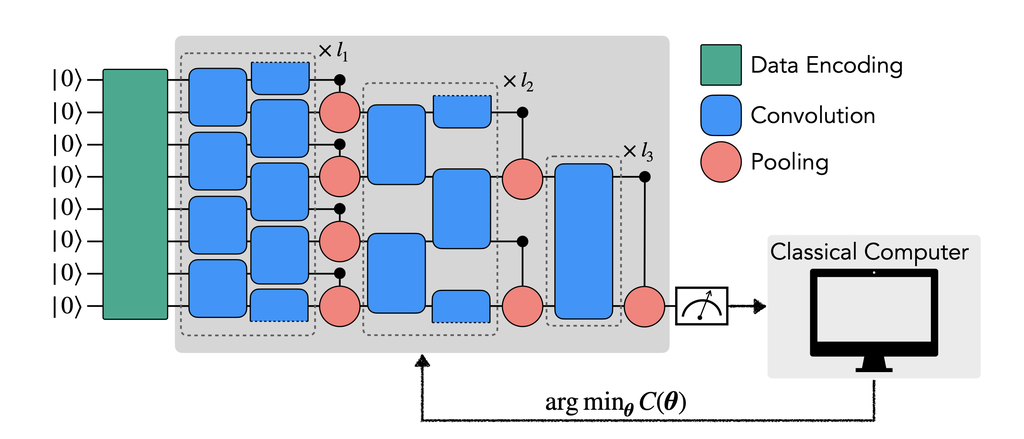

### 0. Data loading

First we load MNIST datasets for classification.

```python
import pennylane as qml
from pennylane import numpy as np
import tensorflow as tf
```

```python
(x_train, y_train), (x_test, y_test) = tf.keras.datasets.mnist.load_data()
x_train, x_test = x_train[..., np.newaxis] / 255.0, x_test[..., np.newaxis] / 255.0
```

Filter class 0 and 1 of MNIST dataset for binary classification tasks

```python
x_train_filter_01 = np.where((y_train == 0) | (y_train == 1))
x_test_filter_01 = np.where((y_test == 0) | (y_test == 1))

X_train, X_test = x_train[x_train_filter_01], x_test[x_test_filter_01]
Y_train, Y_test = y_train[x_train_filter_01], y_test[x_test_filter_01]
```

Resize 28 * 28 image into 256 vectors so we can fit into 8 qubit QCNN model

```python
X_train = tf.image.resize(X_train[:], (256, 1)).numpy()
X_test = tf.image.resize(X_test[:], (256, 1)).numpy()
X_train, X_test = tf.squeeze(X_train).numpy(), tf.squeeze(X_test).numpy()
```

### 1. Quantum Embedding

In order to process classical data with quantum hardware, we must first map classical data in a quantum state. Here, we will use Amplitude Embedding scheme.

```python
def data_embedding(X):
    qml.AmplitudeEmbedding(X, wires=range(8), normalize=True)
```

### 2. Unitary Ansatz

QCNN model utilizes local trainable unitaries. Here, we are interested in 2-local architecture. Below is parameterized circuit that can express general SU4 unitaries with 15 parameters.

```python
def U_SU4(params, wires): # 15 params
    qml.U3(params[0], params[1], params[2], wires=wires[0])
    qml.U3(params[3], params[4], params[5], wires=wires[1])
    qml.CNOT(wires=[wires[0], wires[1]])
    qml.RY(params[6], wires=wires[0])
    qml.RZ(params[7], wires=wires[1])
    qml.CNOT(wires=[wires[1], wires[0]])
    qml.RY(params[8], wires=wires[0])
    qml.CNOT(wires=[wires[0], wires[1]])
    qml.U3(params[9], params[10], params[11], wires=wires[0])
    qml.U3(params[12], params[13], params[14], wires=wires[1])
```

### 3. QCNN Circuit

Here, we will define a QCNN structure. For convolutional layer, we will consider all two nearest neighbour two qubit unitaries. We will assume periodic boundary condition where the first qubit and the last qubits are connected as well. For the pooling layer, we will trace out the qubits without applying any additional gates.

```python
def conv_layer1(U, params):
    U(params, wires=[0, 7])
    for i in range(0, 8, 2):
        U(params, wires=[i, i + 1])
    for i in range(1, 7, 2):
        U(params, wires=[i, i + 1])
def conv_layer2(U, params):
    U(params, wires=[0, 6])
    U(params, wires=[0, 2])
    U(params, wires=[4, 6])
    U(params, wires=[2, 4])
def conv_layer3(U, params):
    U(params, wires=[0,4])
```

```python
def QCNN_structure_without_pooling(U, params):
    param1 = params[0:15]
    param2 = params[15:30]
    param3 = params[30:45]

    conv_layer1(U, param1)
    conv_layer2(U, param2)
    conv_layer3(U, param3)
```

Full QCNN model can be constructed by concatenating data embedding, QCNN ansatz, and measurement.

```python
dev = qml.device('default.qubit', wires = 8)
@qml.qnode(dev)
def QCNN(X, params):

    data_embedding(X)
    QCNN_structure_without_pooling(U_SU4, params)
    result = qml.expval(qml.PauliZ(4))
    return result
```

### 5. Training

We train QCNN model with MSE loss fucntion. Here, we will train for 100 steps, with batch size 25 and learning rate 0.01.

```python
def square_loss(labels, predictions):
    loss = 0
    for l, p in zip(labels, predictions):
        loss = loss + (l - p) ** 2
    loss = loss / len(labels)
    return loss
```

```python
def cost(params, X, Y):
    predictions = [QCNN(x, params) for x in X]
    loss = square_loss(Y, predictions)
    return loss
```

```python
steps = 100
learning_rate = 0.01
batch_size = 25


params = np.random.randn(45, requires_grad=True)
opt = qml.NesterovMomentumOptimizer(stepsize=learning_rate)
loss_history = []

for it in range(steps):
    batch_index = np.random.randint(0, len(X_train), (batch_size,))
    X_batch = [X_train[i] for i in batch_index]
    Y_batch = [Y_train[i] for i in batch_index]
    params, cost_new = opt.step_and_cost(lambda v: cost(v, X_batch, Y_batch), params)
    loss_history.append(cost_new)
    if it % 10 == 0:
        print("iteration: ", it, " cost: ", cost_new)
```

```
iteration:  0  cost:  0.49934547842218835
iteration:  10  cost:  0.2503536678322024
iteration:  20  cost:  0.11762641399484976
iteration:  30  cost:  0.07426772535056775
iteration:  40  cost:  0.07729063180222724
iteration:  50  cost:  0.09388518272820143
iteration:  60  cost:  0.0797389077599842
iteration:  70  cost:  0.08666048601336815
iteration:  80  cost:  0.0826604040027213
iteration:  90  cost:  0.0870977108502367
```

### 6. Accuracy Test

As we trained QCNN models, let's see how well it can classify the images.

```python
def accuracy_test(predictions, labels):
    acc = 0
    for l, p in zip(labels, predictions):
        if np.abs(l - p) < 0.5:
            acc = acc + 1
    return acc / len(labels)
```

```python
predictions = [QCNN(x, params) for x in X_test]
accuracy = accuracy_test(predictions, Y_test)
accuracy = accuracy * 100
```

```python
print(f"Test data accuracy with QCNN model: {accuracy:.3}%")
```

```
Test data accuracy with QCNN model: 95.8%
```

Our simple QCNN model classifies the MNIST data with 95.8% accuracy!

In this introductory tutorial, we only looked at QCNN with resizing (interpolation) classical preprocessing, amplitude embedding, SU4 ansatz without pooling layer, MSE loss function applied on MNIST datasets. If you want to see more of the results, look at the original paper and code!

### References

1. Tak Hur, Leeseok Kim, and Daniel K Park, “Quantum convolutional neural network for classical data classification,” (2022).
2. Iris Cong, Soonwon Choi, and Mikhail D. Lukin. Quantum convolutional neural networks. Nature Physics, 15(12):1273-1278, December 2019